# Como sinais multimodais influenciam o tempo até o início do amplexo?

### 4.1.2 Área fixa em 50

#### 4.1.2.1 Análise exploratória

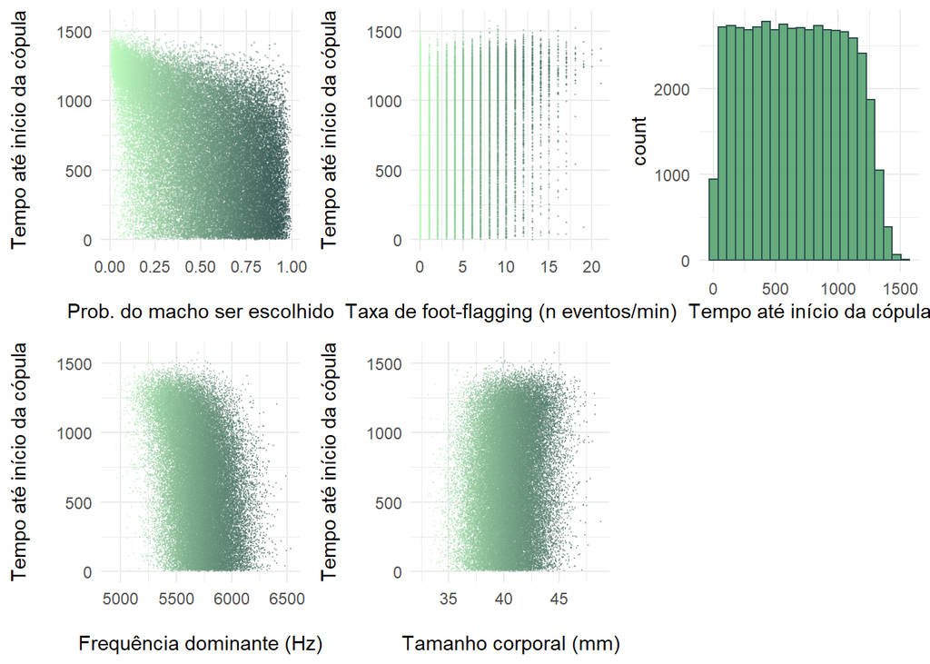

```r
AED(sim_Afix50, binw = 70)
```

#### 4.1.2.2 Seleção de modelos

**Modelos com área fixa em 50**

```r
# 1. GLMM Cheio: efeito aleatório das cachoeiras sobre o intercepto + efeito fixo com tripla interação
glmm50.1 = glmer(ttot~tamapad*freqpad*footpad + (1|nsim), family=Gamma(link = "log"), data=sim_Afix50)

# 2. GLMM sem tripla
glmm50.2 = glmer(ttot~tamapad+freqpad+footpad+tamapad:freqpad+tamapad:footpad+freqpad:footpad + (1|nsim), family=Gamma(link = "log"), data=sim_Afix50)

# 3. GLMM sem 1 dupla: freqpad:footpad
glmm50.3 = glmer(ttot~tamapad+freqpad+footpad+tamapad:freqpad+tamapad:footpad + (1|nsim), family=Gamma(link = "log"), data=sim_Afix50)

# 4. GLMM sem 1 dupla: tamapad:footpad
glmm50.4 = glmer(ttot~tamapad+freqpad+footpad+tamapad:freqpad+freqpad:footpad + (1|nsim), family=Gamma(link = "log"), data=sim_Afix50)

# 5. GLMM sem 1 dupla: tamapad:freqpad
glmm50.5 = glmer(ttot~tamapad+freqpad+footpad+tamapad:footpad+freqpad:footpad + (1|nsim), family=Gamma(link = "log"), data=sim_Afix50)

# 6. GLMM sem 2 duplas: freqpad:footpad e tamapad:footpad
glmm50.6 = glmer(ttot~tamapad+freqpad+footpad+tamapad:freqpad + (1|nsim), family=Gamma(link = "log"), data=sim_Afix50)

# 7. GLMM sem 2 duplas: tamapad:footpad e tamapad:freqpad
glmm50.7 = glmer(ttot~tamapad+freqpad+footpad+freqpad:footpad + (1|nsim), family=Gamma(link = "log"), data=sim_Afix50)

# 8. GLMM sem 2 duplas: freqpad:footpad e tamapad:freqpad
glmm50.8 = glmer(ttot~tamapad+freqpad+footpad+tamapad:footpad + (1|nsim), family=Gamma(link = "log"), data=sim_Afix50)

# 9. GLMM sem nenhuma dupla
glmm50.9 = glmer(ttot~tamapad+freqpad+footpad + (1|nsim), family=Gamma(link = "log"), data=sim_Afix50)

# 10. GLMM sem freqpad
glmm50.10 = glmer(ttot~tamapad+footpad + (1|nsim), family=Gamma(link = "log"), data=sim_Afix50)

# 11. GLMM sem footpad
glmm50.11 = glmer(ttot~tamapad+freqpad + (1|nsim), family=Gamma(link = "log"), data=sim_Afix50)

# 12. GLMM sem tamapad
glmm50.12 = glmer(ttot~freqpad+footpad + (1|nsim), family=Gamma(link = "log"), data=sim_Afix50)

# 13. GLMM só com freqpad
glmm50.13 = glmer(ttot~freqpad + (1|nsim), family=Gamma(link = "log"), data=sim_Afix50)

# 14. GLMM só com footpad
glmm50.14 = glmer(ttot~footpad + (1|nsim), family=Gamma(link = "log"), data=sim_Afix50)

# 15. GLMM só com tamapad
glmm50.15 = glmer(ttot~tamapad + (1|nsim), family=Gamma(link = "log"), data=sim_Afix50)
```

```r
# Seleção de modelo
models50 = c(glmm50.1, glmm50.2, glmm50.3, glmm50.4, glmm50.5, glmm50.6, glmm50.7, glmm50.8, glmm50.9, glmm50.10, glmm50.11, glmm50.12, glmm50.13, glmm50.14, glmm50.15)
model.names50 = gsub("10", "50", model.names10)
aictab(cand.set=models50, modnames=model.names50)
```

```
##
## Model selection based on AICc:
##
##            K     AICc Delta_AICc AICcWt Cum.Wt        LL
## glmm50.1  10 730792.0       0.00      1      1 -365386.0
## glmm50.6   7 730817.2      25.23      0      1 -365401.6
## glmm50.4   8 730817.5      25.48      0      1 -365400.8
## glmm50.3   8 730818.0      25.96      0      1 -365401.0
## glmm50.2   9 730818.1      26.12      0      1 -365400.1
## glmm50.9   6 730847.0      54.97      0      1 -365417.5
## glmm50.8   7 730847.5      55.48      0      1 -365416.8
## glmm50.7   7 730848.1      56.07      0      1 -365417.0
## glmm50.5   8 730848.6      56.54      0      1 -365416.3
## glmm50.12  5 731700.7     908.64      0      1 -365845.3
## glmm50.11  5 733843.6    3051.62      0      1 -366916.8
## glmm50.13  4 734473.7    3681.70      0      1 -367232.9
## glmm50.50  5 734968.4    4176.41      0      1 -367479.2
## glmm50.14  4 735812.3    5020.27      0      1 -367902.1
## glmm50.15  4 737824.6    7032.55      0      1 -368908.3
```

#### 4.1.2.3 Modelo mínimo adequado

```r
# Sumário do melhor modelo
summary(glmm50.1)
```

```
## Generalized linear mixed model fit by maximum likelihood (Laplace
##   Approximation) [glmerMod]
##  Family: Gamma  ( log )
## Formula: ttot ~ tamapad * freqpad * footpad + (1 | nsim)
##    Data: sim_Afix50
##
##       AIC       BIC    logLik  deviance  df.resid
##  730792.0  730880.2 -365386.0  730772.0     49990
##
## Scaled residuals:
##     Min      1Q  Median      3Q     Max
## -1.8449 -0.7943  0.0568  0.7101  4.9793
##
## Random effects:
##  Groups   Name        Variance  Std.Dev.
##  nsim     (Intercept) 0.0002423 0.01557
##  Residual             0.2930393 0.54133
## Number of obs: 50000, groups:  nsim, 1000
##
## Fixed effects:
##                          Estimate Std. Error  t value Pr(>|z|)
## (Intercept)              6.451712   0.003118 2069.116  < 2e-16 ***
## tamapad                  0.089431   0.003032   29.491  < 2e-16 ***
## freqpad                 -0.195155   0.003001  -65.036  < 2e-16 ***
## footpad                  0.162116   0.003050   53.150  < 2e-16 ***
## tamapad:freqpad         -0.016463   0.003021   -5.450 5.04e-08 ***
## tamapad:footpad          0.003539   0.003059    1.157    0.247
## freqpad:footpad         -0.002305   0.003148   -0.732    0.464
## tamapad:freqpad:footpad  0.016955   0.003197    5.303 1.14e-07 ***
## ---
## Signif. codes:  0 '***' 0.001 '**' 0.01 '*' 0.05 '.' 0.1 ' ' 1
##
## Correlation of Fixed Effects:
##             (Intr) tamapd freqpd footpd tmpd:fr tmpd:ft frqpd:
## tamapad     -0.001
## freqpad      0.003  0.000
## footpad      0.003  0.064  0.008
## tampd:frqpd  0.002 -0.004  0.030 -0.005
## tamapd:ftpd  0.061  0.004 -0.005  0.081  0.012
## freqpd:ftpd  0.009 -0.005  0.046 -0.007  0.074  -0.006
## tmpd:frqpd: -0.004  0.013  0.075 -0.006  0.045  -0.002   0.116
```

```r
# Intervalo de confiança dos coeficientes das preditoras
# conf10.1 = confint(glmm10.1, method="Wald")
```

### 4.1.3 Área fixa em 100

#### 4.1.3.1 Análise exploratória

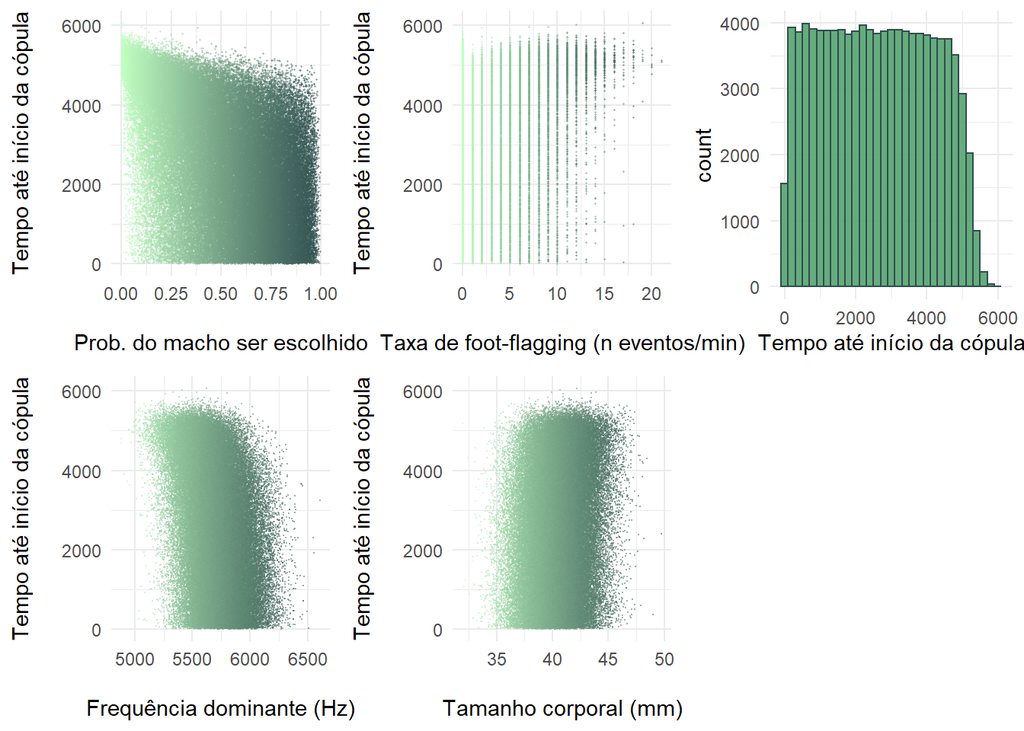

```r
AED(sim_Afix100, binw = 200)
```

#### 4.1.3.2 Seleção de modelos

**Modelos com área fixa em 100**

```r
# 1. GLMM Cheio: efeito aleatório das cachoeiras sobre o intercepto + efeito fixo com tripla interação
glmm100.1 = glmer(ttot~tamapad*freqpad*footpad + (1|nsim), family=Gamma(link = "log"), data=sim_Afix100)

# 2. GLMM sem tripla
glmm100.2 = glmer(ttot~tamapad+freqpad+footpad+tamapad:freqpad+tamapad:footpad+freqpad:footpad + (1|nsim), family=Gamma(link = "log"), data=sim_Afix100)

# 3. GLMM sem 1 dupla: freqpad:footpad
glmm100.3 = glmer(ttot~tamapad+freqpad+footpad+tamapad:freqpad+tamapad:footpad + (1|nsim), family=Gamma(link = "log"), data=sim_Afix100)

# 4. GLMM sem 1 dupla: tamapad:footpad
glmm100.4 = glmer(ttot~tamapad+freqpad+footpad+tamapad:freqpad+freqpad:footpad + (1|nsim), family=Gamma(link = "log"), data=sim_Afix100)

# 5. GLMM sem 1 dupla: tamapad:freqpad
glmm100.5 = glmer(ttot~tamapad+freqpad+footpad+tamapad:footpad+freqpad:footpad + (1|nsim), family=Gamma(link = "log"), data=sim_Afix100)

# 6. GLMM sem 2 duplas: freqpad:footpad e tamapad:footpad
glmm100.6 = glmer(ttot~tamapad+freqpad+footpad+tamapad:freqpad + (1|nsim), family=Gamma(link = "log"), data=sim_Afix100)

# 7. GLMM sem 2 duplas: tamapad:footpad e tamapad:freqpad
glmm100.7 = glmer(ttot~tamapad+freqpad+footpad+freqpad:footpad + (1|nsim), family=Gamma(link = "log"), data=sim_Afix100)

# 8. GLMM sem 2 duplas: freqpad:footpad e tamapad:freqpad
glmm100.8 = glmer(ttot~tamapad+freqpad+footpad+tamapad:footpad + (1|nsim), family=Gamma(link = "log"), data=sim_Afix100)

# 9. GLMM sem nenhuma dupla
glmm100.9 = glmer(ttot~tamapad+freqpad+footpad + (1|nsim), family=Gamma(link = "log"), data=sim_Afix100)

# 10. GLMM sem freqpad
glmm100.10 = glmer(ttot~tamapad+footpad + (1|nsim), family=Gamma(link = "log"), data=sim_Afix100)

# 11. GLMM sem footpad
glmm100.11 = glmer(ttot~tamapad+freqpad + (1|nsim), family=Gamma(link = "log"), data=sim_Afix100)

# 12. GLMM sem tamapad
glmm100.12 = glmer(ttot~freqpad+footpad + (1|nsim), family=Gamma(link = "log"), data=sim_Afix100)

# 13. GLMM só com freqpad
glmm100.13 = glmer(ttot~freqpad + (1|nsim), family=Gamma(link = "log"), data=sim_Afix100)

# 14. GLMM só com footpad
glmm100.14 = glmer(ttot~footpad + (1|nsim), family=Gamma(link = "log"), data=sim_Afix100)

# 15. GLMM só com tamapad
glmm100.15 = glmer(ttot~tamapad + (1|nsim), family=Gamma(link = "log"), data=sim_Afix100)
```

```r
# Seleção de modelo
models100 = c(glmm100.1, glmm100.2, glmm100.3, glmm100.4, glmm100.5, glmm100.6, glmm100.7, glmm100.8, glmm100.9, glmm100.10, glmm100.11, glmm100.12, glmm100.13, glmm100.14, glmm100.15)
model.names100 = gsub("10", "100", model.names10)
aictab(cand.set=models100, modnames=model.names100)
```

```
##
## Model selection based on AICc:
##
##              K    AICc Delta_AICc AICcWt Cum.Wt        LL
## glmm100.1   10 1739183       0.00      1      1 -869581.5
## glmm100.2    9 1739220      36.86      0      1 -869600.9
## glmm100.4    8 1739222      38.56      0      1 -869602.8
## glmm100.3    8 1739230      46.68      0      1 -869606.9
## glmm100.6    7 1739231      47.92      0      1 -869608.5
## glmm100.5    8 1739282      98.69      0      1 -869632.9
## glmm100.7    7 1739283      99.95      0      1 -869634.5
## glmm100.8    7 1739294     110.94      0      1 -869640.0
## glmm100.9    6 1739295     111.94      0      1 -869641.5
## glmm100.12   5 1741138    1954.68      0      1 -870563.9
## glmm100.11   5 1744864    5680.66      0      1 -872426.8
## glmm100.13   4 1746310    7126.50      0      1 -873150.8
## glmm100.100  5 1747536    8352.90      0      1 -873763.0
## glmm100.14   4 1749364   10180.78      0      1 -874677.9
## glmm100.15   4 1752738   13555.27      0      1 -876365.2
```

#### 4.1.3.3 Modelo mínimo adequado

```r
# Sumário do melhor modelo
summary(glmm100.1)
```

```
## Generalized linear mixed model fit by maximum likelihood (Laplace
##   Approximation) [glmerMod]
##  Family: Gamma  ( log )
## Formula: ttot ~ tamapad * freqpad * footpad + (1 | nsim)
##    Data: sim_Afix100
##
##       AIC       BIC    logLik  deviance  df.resid
## 1739183.0 1739278.2 -869581.5 1739163.0     99990
##
## Scaled residuals:
##     Min      1Q  Median      3Q     Max
## -1.8367 -0.8047  0.0548  0.7215  4.7467
##
## Random effects:
##  Groups   Name        Variance  Std.Dev.
##  nsim     (Intercept) 7.576e-06 0.002752
##  Residual             2.962e-01 0.544240
## Number of obs: 100000, groups:  nsim, 1000
##
## Fixed effects:
##                          Estimate Std. Error  t value Pr(>|z|)
## (Intercept)              7.825585   0.002185 3581.393  < 2e-16 ***
## tamapad                  0.094139   0.002177   43.238  < 2e-16 ***
## freqpad                 -0.198019   0.002148  -92.176  < 2e-16 ***
## footpad                  0.154656   0.002216   69.802  < 2e-16 ***
## tamapad:freqpad         -0.016827   0.002157   -7.802 6.11e-15 ***
## tamapad:footpad         -0.004012   0.002233   -1.796   0.0724 .
## freqpad:footpad          0.009514   0.002288    4.159 3.20e-05 ***
## tamapad:freqpad:footpad  0.014221   0.002280    6.237 4.47e-10 ***
## ---
## Signif. codes:  0 '***' 0.001 '**' 0.01 '*' 0.05 '.' 0.1 ' ' 1
##
## Correlation of Fixed Effects:
##             (Intr) tamapd freqpd footpd tmpd:fr tmpd:ft frqpd:
## tamapad      0.000
## freqpad      0.001  0.001
## footpad      0.004  0.045  0.011
## tampd:frqpd  0.001 -0.009  0.024 -0.001
## tamapd:ftpd  0.045  0.010 -0.001  0.105  0.015
## freqpd:ftpd  0.011 -0.001  0.038  0.020  0.045   0.004
## tmpd:frqpd: -0.001  0.015  0.046  0.004  0.030   0.020   0.119
```

```r
# Intervalo de confiança dos coeficientes das preditoras
# conf10.1 = confint(glmm10.1, method="Wald")
```

## 4.2 Simulação com área variável

### 4.2.1 Análise exploratória

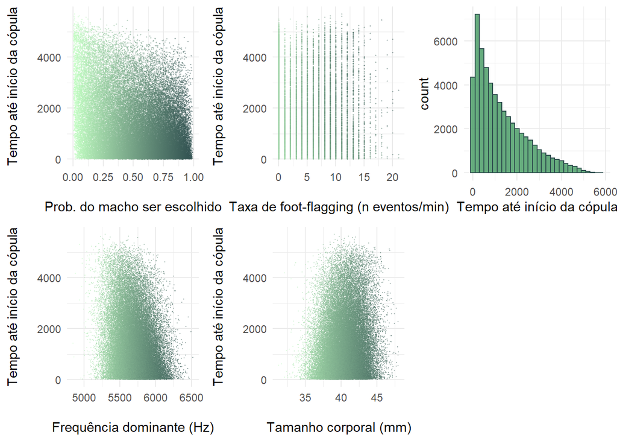

```r
AED(sim_Avar, binw = 200)
```

### 4.2.2 Seleção de modelos

**Modelos com área variável**

```r
# 1. GLMM Cheio: efeito aleatório das cachoeiras sobre o intercepto + efeito fixo com tripla interação
glmmvar.1 = glmer(ttot~tamapad*freqpad*footpad + (1|nsim), family=Gamma(link = "log"), data=sim_Avar)

# 2. GLMM sem tripla
glmmvar.2 = glmer(ttot~tamapad+freqpad+footpad+tamapad:freqpad+tamapad:footpad+freqpad:footpad + (1|nsim), family=Gamma(link = "log"), data=sim_Avar)

# 3. GLMM sem 1 dupla: freqpad:footpad
glmmvar.3 = glmer(ttot~tamapad+freqpad+footpad+tamapad:freqpad+tamapad:footpad + (1|nsim), family=Gamma(link = "log"), data=sim_Avar)

# 4. GLMM sem 1 dupla: tamapad:footpad
glmmvar.4 = glmer(ttot~tamapad+freqpad+footpad+tamapad:freqpad+freqpad:footpad + (1|nsim), family=Gamma(link = "log"), data=sim_Avar)

# 5. GLMM sem 1 dupla: tamapad:freqpad
glmmvar.5 = glmer(ttot~tamapad+freqpad+footpad+tamapad:footpad+freqpad:footpad + (1|nsim), family=Gamma(link = "log"), data=sim_Avar)

# 6. GLMM sem 2 duplas: freqpad:footpad e tamapad:footpad
glmmvar.6 = glmer(ttot~tamapad+freqpad+footpad+tamapad:freqpad + (1|nsim), family=Gamma(link = "log"), data=sim_Avar)

# 7. GLMM sem 2 duplas: tamapad:footpad e tamapad:freqpad
glmmvar.7 = glmer(ttot~tamapad+freqpad+footpad+freqpad:footpad + (1|nsim), family=Gamma(link = "log"), data=sim_Avar)

# 8. GLMM sem 2 duplas: freqpad:footpad e tamapad:freqpad
glmmvar.8 = glmer(ttot~tamapad+freqpad+footpad+tamapad:footpad + (1|nsim), family=Gamma(link = "log"), data=sim_Avar)

# 9. GLMM sem nenhuma dupla
glmmvar.9 = glmer(ttot~tamapad+freqpad+footpad + (1|nsim), family=Gamma(link = "log"), data=sim_Avar)

# 10. GLMM sem freqpad
glmmvar.10 = glmer(ttot~tamapad+footpad + (1|nsim), family=Gamma(link = "log"), data=sim_Avar)

# 11. GLMM sem footpad
glmmvar.11 = glmer(ttot~tamapad+freqpad + (1|nsim), family=Gamma(link = "log"), data=sim_Avar)

# 12. GLMM sem tamapad
glmmvar.12 = glmer(ttot~freqpad+footpad + (1|nsim), family=Gamma(link = "log"), data=sim_Avar)

# 13. GLMM só com freqpad
glmmvar.13 = glmer(ttot~freqpad + (1|nsim), family=Gamma(link = "log"), data=sim_Avar)

# 14. GLMM só com footpad
glmmvar.14 = glmer(ttot~footpad + (1|nsim), family=Gamma(link = "log"), data=sim_Avar)

# 15. GLMM só com tamapad
glmmvar.15 = glmer(ttot~tamapad + (1|nsim), family=Gamma(link = "log"), data=sim_Avar)
```

```r
# Seleção de modelo
modelsvar = c(glmmvar.1, glmmvar.2, glmmvar.3, glmmvar.4, glmmvar.5, glmmvar.6, glmmvar.7, glmmvar.8, glmmvar.9, glmmvar.10, glmmvar.11, glmmvar.12, glmmvar.13, glmmvar.14, glmmvar.15)
model.namesvar = gsub("10", "var", model.names10)
aictab(cand.set=modelsvar, modnames=model.namesvar)
```

```
##
## Model selection based on AICc:
##
##              K     AICc Delta_AICc AICcWt Cum.Wt        LL
## glmmvar.1   10 848738.7       0.00      1      1 -424359.4
## glmmvar.6    7 848766.1      27.34      0      1 -424376.0
## glmmvar.4    8 848767.4      28.65      0      1 -424375.7
## glmmvar.3    8 848767.5      28.82      0      1 -424375.8
## glmmvar.2    9 848768.8      30.10      0      1 -424375.4
## glmmvar.9    6 848788.5      49.74      0      1 -424388.2
## glmmvar.8    7 848789.9      51.16      0      1 -424387.9
## glmmvar.7    7 848790.1      51.41      0      1 -424388.1
## glmmvar.5    8 848791.6      52.82      0      1 -424387.8
## glmmvar.12   5 849736.8     998.05      0      1 -424863.4
## glmmvar.11   5 851905.2    3166.52      0      1 -425947.6
## glmmvar.13   4 852627.1    3888.40      0      1 -426309.6
## glmmvar.var  5 853527.4    4788.70      0      1 -426758.7
## glmmvar.14   4 854476.1    5737.35      0      1 -427234.0
## glmmvar.15   4 856489.6    7750.89      0      1 -428240.8
```

### 4.2.3 Modelo mínimo adequado

```r
summary(glmmvar.1)
```

```
## Generalized linear mixed model fit by maximum likelihood (Laplace
##   Approximation) [glmerMod]
##  Family: Gamma  ( log )
## Formula: ttot ~ tamapad * freqpad * footpad + (1 | nsim)
##    Data: sim_Avar
##
##       AIC       BIC    logLik  deviance  df.resid
##  848738.7  848827.8 -424359.4  848718.7     54627
##
## Scaled residuals:
##     Min      1Q  Median      3Q     Max
## -1.8076 -0.7841  0.0609  0.7043  4.7296
##
## Random effects:
##  Groups   Name        Variance Std.Dev.
##  nsim     (Intercept) 0.4178   0.6464
##  Residual             0.3049   0.5522
## Number of obs: 54637, groups:  nsim, 1000
##
## Fixed effects:
##                           Estimate Std. Error t value Pr(>|z|)
## (Intercept)              6.3406961  0.0369208 171.738  < 2e-16 ***
## tamapad                  0.0901779  0.0029069  31.022  < 2e-16 ***
## freqpad                 -0.2005450  0.0028713 -69.845  < 2e-16 ***
## footpad                  0.1571145  0.0029310  53.605  < 2e-16 ***
## tamapad:freqpad         -0.0139362  0.0029286  -4.759 1.95e-06 ***
## tamapad:footpad          0.0018637  0.0029865   0.624    0.533
## freqpad:footpad         -0.0007389  0.0030512  -0.242    0.809
## tamapad:freqpad:footpad  0.0175438  0.0030948   5.669 1.44e-08 ***
## ---
## Signif. codes:  0 '***' 0.001 '**' 0.01 '*' 0.05 '.' 0.1 ' ' 1
##
## Correlation of Fixed Effects:
##             (Intr) tamapd freqpd footpd tmpd:fr tmpd:ft frqpd:
## tamapad      0.000
## freqpad      0.000  0.005
## footpad      0.001  0.057  0.011
## tampd:frqpd  0.000 -0.002  0.014 -0.001
## tamapd:ftpd  0.005  0.006 -0.001  0.097  0.005
## freqpd:ftpd  0.001  0.000  0.042  0.001  0.059   0.008
## tmpd:frqpd:  0.000  0.005  0.059  0.009  0.037  -0.023   0.108
```

# 5 Discussão

# 6 Referências

Bolker at al 2022. GLMM FAQ https://bbolker.github.io/mixedmodels-misc/glmmFAQ.html#reml-for-glmms.

Duellman, W. E., & Trueb, L. (1986). Biology of Amphibians McGraw-Hill Inc. Nueva York, EUA.

Gingras, B., Mohandesan, E., Boko, D., & Fitch, W. (2013). Phylogenetic signal in the acoustic parameters of the advertisement calls of four clades of anurans. BMC Evolutionary Biology, 13(1), 1-12.

Goutte, S., Dubois, A., & Legendre, F. (2013). The importance of ambient sound level to characterise anuran habitat. Plos One, 8(10), e78020.

Haddad, C. F., & Giaretta, A. A. (1999). Visual and acoustic communication in the Brazilian torrent frog, *Hylodes asper* (Anura: Leptodactylidae). Herpetologica, 324-333.

Heyer, W. R., Rand, A. S., da Cruz, C. A. G., Peixoto, O. L., & Nelson, C. E. (1990). Frogs of Boracéia. Arquivos de Zoologia, 31(4), 231-410.

Hödl, W., Rodrigues, M. T., Accacio, G. M., Lara, P. H., Pavan, D., Schiesari, L., & Skuk, G. (1997). Foot-flagging display in the Brazilian stream-breeding frog *Hylodes asper* (Leptodactylidae). Scientific film, Ctf, 2703.

Köhler, J., Jansen, M., Rodríguez, A., Kok, P. J. R., Toledo, L. F., Emmrich, M., Glaw F., Haddad, C. F. B., Rodel, M., Vences, M. (2017). The use of bioacoustics in anuran taxonomy: Theory, terminology, methods and recommendations for best practice. Zootaxa, 4251, 1–124.

Lo, Steson, and Sally Andrews. 2015. “To Transform or Not to Transform: Using Generalized Linear Mixed Models to Analyse Reaction Time Data.” Frontiers in Psychology 6. https://doi.org/10.3389/fpsyg.2015.01171.

Martin, W. F. (1971). Mechanics of sound production in toads of the genus Bufo: passive elements. Journal of Experimental Zoology, 176(3), 273-293.

McClelland, B. E., Wilczynski, W. A. L. T. E. R., & Ryan, M. J. (1996). Correlations between call characteristics and morphology in male cricket frogs (Acris crepitans). The Journal of Experimental Biology, 199(9), 1907-1919.

Ryan, M. J. (1988). Constraints and patterns in the evolution of anuran acoustic communication. The evolution of the amphibian auditory system, 637-677.

Schmid, E. (1978). Contribution to the morphology and histology of the vocal cords of Central European anurans (Amphibia). Zoologische Jahrbucher Anatomie, 5, 133-150.

Wells, K. D. (1977). The social behaviour of anuran amphibians. Animal Behaviour, 25, 666-693.